Notebook created by Jan Gądek

**Digital Signal Processing Lab**

**FIR Filters**

# Introduction

FIR filter is a filter whose impulse response is of finite duration. In this notebook you will have to implement a few exercises that will expose you to FIR filter design methods.

## Reading list

Before working with the notebook, you might find it useful to become acquainted with the following materials:

- Section **12.1 Wprowadzenie** from “Cyfrowe przetwarzanie sygnałów : od teorii do zastosowań, WKŁ 2014” by T. P. Zieliński.
- Section **12.2 Metoda próbkowania w dziedzinie częstotliwości** from “Cyfrowe przetwarzanie sygnałów : od teorii do zastosowań, WKŁ 2014” by T. P. Zieliński.
- Section **12.5 Metoda okien** from “Cyfrowe przetwarzanie sygnałów : od teorii do zastosowań, WKŁ 2014” by T. P. Zieliński.

# Necessary imports

You should not import anything else in order to complete exercises in this notebook.

```python
import numpy as np
import matplotlib.pyplot as plt
```

Sample FIR that will be used in first part of this notebook. DO NOT CHANGE ANY OF THE COEFFICIENTS!

```python
example_FIR = np.array([ 0.01097947, -0.01154252, -0.01216644,  0.01286166,  0.01364116,
       -0.01452123, -0.0155227 ,  0.01667252,  0.01800633, -0.01957209,
       -0.0214361 ,  0.02369253,  0.02647989, -0.03001054, -0.03462755,
        0.04092347,  0.05001757, -0.06430831, -0.09003163,  0.15005272,
        0.45015816,  0.45015816,  0.15005272, -0.09003163, -0.06430831,
        0.05001757,  0.04092347, -0.03462755, -0.03001054,  0.02647989,
        0.02369253, -0.0214361 , -0.01957209,  0.01800633,  0.01667252,
       -0.0155227 , -0.01452123,  0.01364116,  0.01286166, -0.01216644,
       -0.01154252])
```

## Usefull functions

Feel free to use these functions in this notebook, they can come in handy.

np.fft.fft(); np.convolve(); np.angle(); np.abs();

# Practical problem set

## Frequency amplitude and phase characteristics

### Exercise

Draw frequency [amplitude](https://en.wikipedia.org/wiki/Frequency_response) and [phase](https://en.wikipedia.org/wiki/Phase_response) responses of the filter with coefficients contained in example_FIR. FFT should be calculated at least in 512 points. Answer the questions.

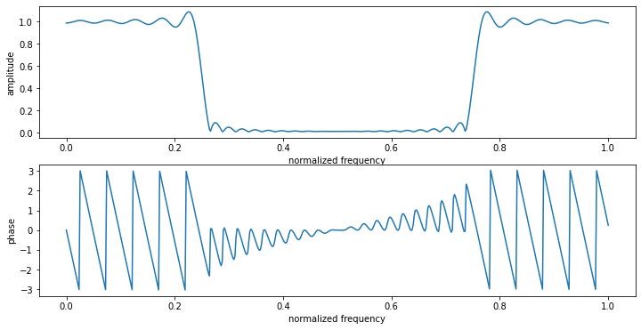

```python
########## Your code goes here ##########
N=512
f_norm=np.linspace(0,1,N)

X=np.fft.fft(example_FIR,N)
H=1 #transformata delty = 1

Y=X

y_magnitude=np.abs(Y)
y_phase=np.angle(Y)

fig=plt.figure()
fig, axes = plt.subplots(figsize=(12,6),nrows=2, ncols=1)

axes[0].plot(f_norm,y_magnitude)
axes[0].set_xlabel('normalized frequency')
axes[0].set_ylabel('amplitude')

axes[1].plot(f_norm, y_phase)
axes[1].set_xlabel('normalized frequency')
axes[1].set_ylabel('phase')
```

### Questions

- Based on the graphs above, answer what type of filter it is (low-pass, high-pass, band-pass, band-stop) and what is its the cutoff frequency.
- Is phase of this filter linear? Why?
- What are the requirements when designing a filter, to achieve linear phase.

hint: $\pi$ and $-\pi$ means the same phase

```
-lowpass
-it is linear in crucial point, using unwrap we can see that it is indeed linear
-stability of the filter
```

## Window method

### Exercise

Implement a function that will design low-pass FIR filter using window method. The algorithm consists of the following steps:

- Selection of the cutoff frequency.
- Selection of the window function.
- Determining the number of filter coefficients.
- Calculation of the ideal filter according to the formula: $$ \large h(n) = \frac{sin(f_{c}2n\pi)}{n\pi} $$ where:
  - n is vector of consecutive numbers of the filter coefficients from -N/2 to N/2,
  - fc is normalized cutoff frequency from 0 to 1.
- Multiplying sinc function with the selected window.

```python
def lp_design_window(fc, N, window):
    """
    This function should design low-pass filter using algorithm presented above.

    Parameters
    ----------
    fc: Int containing cutoff frequency of filter.
    N: Int containing number of filter coefficients.
    window: numpy array of shape (N, ) containing window function.

    Returns
    -------
    h: numpy array of shape (N, ) containing coefficients of filter (impulse response)

    """
    h=np.zeros(N)

    n=np.linspace(-N/2,N/2,N)

    for i in range(N):
        if n[i]==0:
            h[i]=2*fc
        else:
            h[i]=np.sin(fc*2*np.pi*n[i])/(n[i]*np.pi)

    h=h*window

    return h
```

Verify your solution. If spectrum of signal that is filtered using your implementation (on the third graph) is attenuated above 250 Hz similarly to the singal presented on second chart, filter is designed correctly. Check if your implementation works for different cutoff frequencies.

```python
fc = 0.25               # Normalized cutoff frequency
N = 41                  # Number of coefficients
window = np.ones((N))   # Rectangular window
```

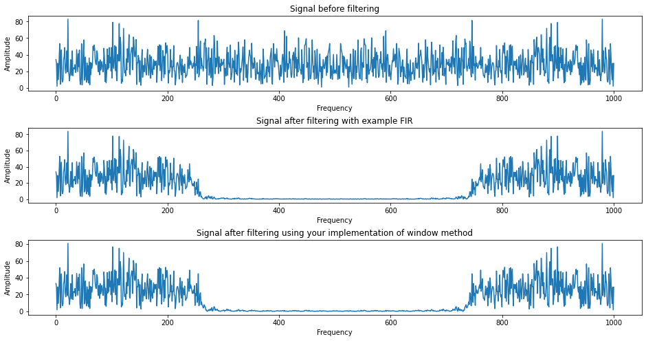

```python
fs = 1000  # Sampling frequency
dt = 1/fs # Sampling interval
t_s = 0   # Start of sampling
t_s = 1   # End of sampling

# Generate timestamps of samples
t = np.arange(0, 1, dt)

# Generate white noise signal
signal = np.random.randn(*t.shape)

# Generate FIR coefficients
lp_filter = lp_design_window(fc, N, window)

# Reference filtering
filtered_ref = np.convolve(signal, example_FIR)

# Signal filtering
filtered = np.convolve(signal, lp_filter)

plt.figure(figsize = (16,8))
plt.subplot(3,1,1)
plt.plot(np.linspace(0,fs,1024), np.abs(np.fft.fft(signal,1024)))
plt.xlabel('Frequency')
plt.ylabel('Amplitude')
plt.title('Signal before filtering')

plt.subplot(3,1,2)
plt.plot(np.linspace(0,fs,1024), np.abs(np.fft.fft(filtered_ref,1024)))
plt.xlabel('Frequency')
plt.ylabel('Amplitude')
plt.title('Signal after filtering with example FIR')

plt.subplot(3,1,3)
plt.plot(np.linspace(0,fs,1024), np.abs(np.fft.fft(filtered,1024)))
plt.xlabel('Frequency')
plt.ylabel('Amplitude')
plt.title('Signal after filtering using your implementation of window method')

plt.subplots_adjust(hspace = 0.5)
plt.show()
```

## Windows and Number of coefficients

### Exercise

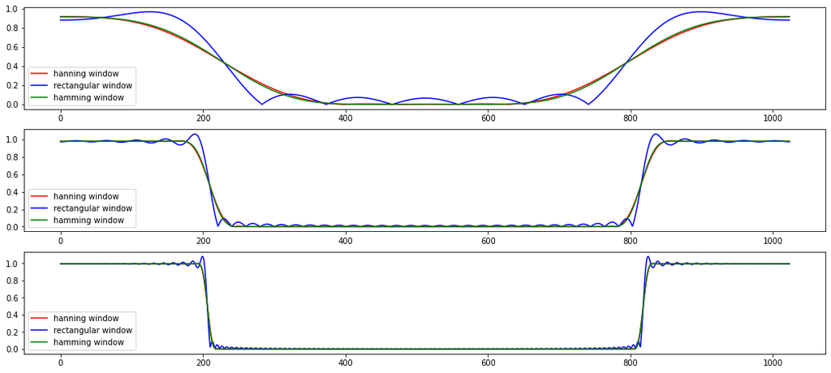

```python
fig=plt.figure()
fig, axes = plt.subplots(figsize=(18,8),nrows=3, ncols=1)

N=[11,51,151]
a=0

for i in N:


    f_norm=(0,1,i)
    fc=0.2

    hann = np.hanning(i)
    hamm = np.hamming(i)
    rec = np.ones((i))

    h_hann=lp_design_window(fc, i, hann)
    H_hann=np.fft.fft(h_hann,1024)

    h_hamm=lp_design_window(fc, i, hamm)
    H_hamm=np.fft.fft(h_hamm,1024)

    rec=lp_design_window(fc, i, rec)
    REC=np.fft.fft(rec,1024)

    axes[a].plot(np.abs(H_hann),'r',label="hanning window")
    axes[a].plot(np.abs(REC),'b',label="rectangular window")
    axes[a].plot(np.abs(H_hamm),'g',label="hamming window")
    axes[a].legend()
    a+=1
```

### Question

- What are the differences when the window is changed?
- What are the differences when the number of coefficients is changed?
- What is the tradeoff between different windows?

```
-precision of created filter
-again, the more coefficients used, the more precise the filter is
-by far the simplest window (rectangular) is the least precise
```

## Frequency Sampling Method

### Exercise

Implement a function that will design a FIR filter with a given characteristic using frequency sampling method. The algorithm consists of the following steps:

- Selection of the cutoff frequency
- Determining the number of filter coefficients
- Determining desired frequency response
- Sampling frequency response
- Performing IFFT
- Shifting coefficients
- Removal of unsymmetrical value

```python
def lp_design_fs(H):
    """
    This function should design FIR filter using algorithm presented above.
    Hint: What are the requirements to get a real signal from idft?
    Parameters
    ----------
    H: Numpy array containing half of the filter frequency response.

    Returns
    -------
    h: numpy array containing coefficients of filter (impulse response).

    """

    N=2*H.size #number of coefficients

    H_l=np.flip(H)
    H_full=np.concatenate([H,H_l]) #full amplitude response

    h=np.fft.ifft(H_full,N)  #ifft

    h_fir=h[:N//2] #circular shift
    h_sec=h[N//2:]
    h=np.concatenate([h_sec,h_fir])

    return h
```

Verify you implementation.

```python
H = np.array([1, 1, 1, 1, 1, 0, 0, 0, 0, 0])       # Half of the frequency amplitude response
```

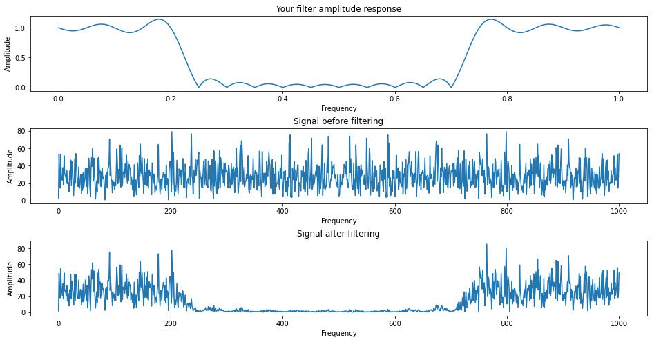

```python
fs = 1e3  # Sampling frequency
dt = 1/fs # Sampling interval
t_s = 0   # Start of sampling
t_s = 1   # End of sampling

# Generate timestamps of samples
t = np.arange(0, 1, dt)

# Generate white noise signal
signal = np.random.randn(*t.shape)

# Generate FIR coefficients
lp_filter = lp_design_fs(H)

# Signal filtering
filtered = np.convolve(signal, lp_filter)

plt.figure(figsize = (16,8))
plt.subplot(3,1,1)
plt.plot(np.linspace(0,1,1000), np.abs(np.fft.fft(lp_filter,1000)))
plt.xlabel('Frequency')
plt.ylabel('Amplitude')
plt.title('Your filter amplitude response')

plt.subplot(3,1,2)
plt.plot(np.linspace(0,fs,1000), np.abs(np.fft.fft(signal,1000)))
plt.xlabel('Frequency')
plt.ylabel('Amplitude')
plt.title('Signal before filtering')

plt.subplot(3,1,3)
plt.plot(np.linspace(0,fs,1000), np.abs(np.fft.fft(filtered,1000)))
plt.xlabel('Frequency')
plt.ylabel('Amplitude')
plt.title('Signal after filtering')

plt.subplots_adjust(hspace = 0.5)
plt.show()
```

### Exercise*

Try to design frequency response above (H) to minimize impact of ripples without changing the number of coefficients.

hint: What is the tradeoff between transition band width and ripples?

## Transitions between filter types

You can easily calculate coefficients of high-pass filter using the relationship between the low-pass and high-pass filters: $$\large h_{hp}[n] = \delta(n) - h_{lp}[n]$$

You can also use fast trick to switch form low-pass to high-pass filter: $$\large h_{hp}[n] = (-1)^{n}h_{lp}[n]$$ hint: Using the second method will shift your cutoff frequency by 0.5.

### Exercise

Implement a function that will design the highpass filter with a given cutoff frequency and number of coefficients using window method. You should use previously implemented functions.

```python
def hp_design(fc, N, window):
    """
    This function should design high-pass filter using low-pass filter.

    Parameters
    ----------
    fc: Int containing cutoff frequency of filter.
    N: Int containing number of filter coefficients.
    window: numpy array of shape (N, ) containing window function.

    Returns
    -------
    h: Numpy array of shape (N, ) containing coefficients of filter (impulse response)

    """

    """ 1st method
    lp=lp_design_window(fc,N,window)
    LP=np.fft.fft(lp,1024)
    HP=1-np.abs(LP)
    h=np.fft.ifft(HP,1024)
    """

    #""" 2nd method
    lp=lp_design_window(0.5-fc,N,window)
    h=np.zeros(lp.size)

    for n in range(lp.size):
        h[n]=lp[n]*(-1)**n
    #"""
    return h
```

Verify your implementation. If filtered signal is attenuated below 250 Hz filter is designed correctly. Check if it works for different cutoff frequencies.

```python
fc = 0.25             # Normalized frequency cutoff
N = 41                  # Number of coefficients
window = np.ones((N))   # Rectangular window
```

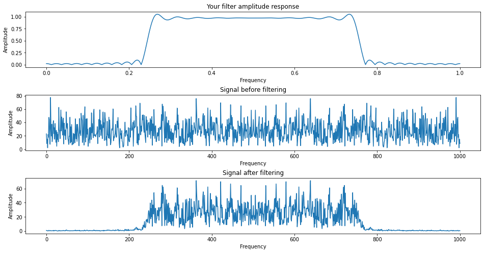

```python
fs = 1e3  # Sampling frequency
dt = 1/fs # Sampling interval
t_s = 0   # Start of sampling
t_s = 1   # End of sampling

# Generate timestamps of samples
t = np.arange(0, 1, dt)

# Generate white noise signal
signal = np.random.randn(*t.shape)

# Generate FIR coefficients
hp_filter = hp_design(fc,N, window)

# Signal filtering
filtered = np.convolve(signal, hp_filter)

plt.figure(figsize = (16,8))
plt.subplot(3,1,1)
plt.plot(np.linspace(0,1,1000), np.abs(np.fft.fft(hp_filter,1000)))
plt.xlabel('Frequency')
plt.ylabel('Amplitude')
plt.title('Your filter amplitude response')

plt.subplot(3,1,2)
plt.plot(np.linspace(0,fs,1000), np.abs(np.fft.fft(signal,1000)))
plt.xlabel('Frequency')
plt.ylabel('Amplitude')
plt.title('Signal before filtering')

plt.subplot(3,1,3)
plt.plot(np.linspace(0,fs,1000), np.abs(np.fft.fft(filtered,1000)))
plt.xlabel('Frequency')
plt.ylabel('Amplitude')
plt.title('Signal after filtering')

plt.subplots_adjust(hspace = 0.5)
plt.show()
```

## Band-pass filters

### Exercise

The final task is to implement the function that will design [band-pass](https://en.wikipedia.org/wiki/Band-pass_filter) filter using window method AND that will perform filtration on imput signal.

Hint: Use previously implemented functions.

```python
def bandpass_filter(signal, fl, fh, N, window):
    """
    This function should design band-pass filter using low-pass and high-pass filter.

    Parameters
    ----------
    signal: numpy array containing signal for filtration.
    fl: Int containing lower cutoff frequency of filter.
    fh: Int containing upper cutoff frequency of filter.
    N: Int containing number of filter coefficients.
    window: numpy array of shape (N, ) containing window function.

    Returns
    -------
    X: numpy array containing filtered signal

    hint: How to obtain band-pass frequency response using low-pass and high-pass filters?
    """
    lp=lp_design_window(fh,N,window)
    hp=hp_design(fl, N, window)

    bp=np.convolve(lp,hp)

    return bp
```

Verify your implementation. Check if it works correctly for different bands.

```python
fl = 0.1               # Band start
fh = 0.4               # Band stop
N = 41                 # Number of coefficients
window = np.ones((N))  # Rectangular window
```

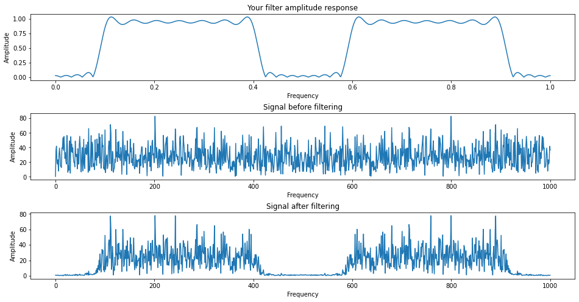

```python
fs = 1e3  # Sampling frequency
dt = 1/fs # Sampling interval
t_s = 0   # Start of sampling
t_s = 1   # End of sampling

# Generate timestamps of samples
t = np.arange(0, 1, dt)

# Generate white noise signal
signal = np.random.randn(*t.shape)

# Generate FIR coefficients
bp_filter = bandpass_filter(signal, fl, fh, N, window)

# Signal filtering
filtered = np.convolve(signal, bp_filter)

plt.figure(figsize = (16,8))
plt.subplot(3,1,1)
plt.plot(np.linspace(0,1,1000), np.abs(np.fft.fft(bp_filter,1000)))
plt.xlabel('Frequency')
plt.ylabel('Amplitude')
plt.title('Your filter amplitude response')

plt.subplot(3,1,2)
plt.plot(np.linspace(0,fs,1000), np.abs(np.fft.fft(signal,1000)))
plt.xlabel('Frequency')
plt.ylabel('Amplitude')
plt.title('Signal before filtering')

plt.subplot(3,1,3)
plt.plot(np.linspace(0,fs,1000), np.abs(np.fft.fft(filtered,1000)))
plt.xlabel('Frequency')
plt.ylabel('Amplitude')
plt.title('Signal after filtering')

plt.subplots_adjust(hspace = 0.5)
plt.show()
```